# Cook County Criminal Judge Severity Ranking (Updated)

Jacob Gosselin

11/9/2018

Hi there! What follows is a written out methodology for *Injustice Watch’s* sentencing analysis on Criminal Division judges. All work was done in R and Stata. The R code and Stata code can be downloaded at our GitHub; since our data is read in from the Cook County Online Data portal, our work can easily be re-created or expanded upon. Thanks!

# Reading in Data/Converting Sentence Term

We’ll start by reading in our original sentencing data (from https://datacatalog.cookcountyil.gov/Courts/Sentencing/tg8v-tm6u). We’ll then create a conversion table to standardize our units (i.e. years=1, months=1/12, weeks=1/52, days=1/365, all other units are left undefined but the rows are kept). We’ll then convert our sentence (i.e. 6 months=.5), and store it under a new variable, “converted_sentence”.

```r
original <- read_csv("https://datacatalog.cookcountyil.gov/api/views/tg8v-tm6u/rows.csv?accessType=DOWNLOAD")
conversion_table <- revalue(original$COMMITMENT_UNIT, c(`Year(s)` = 1,
    Months = 1/12, Weeks = 1/52, Days = 1/365, Pounds = NA, Dollars = NA,
    Term = NA))
conversion_table <- as.double(conversion_table)
original["converted_sentence"] <- ifelse(original$COMMITMENT_UNIT ==
    "Natural Life", 100, conversion_table * as.double(original$COMMITMENT_TERM))
original["sentence_date"] <- as.Date(original$SENTENCE_DATE,
    "%m/%d/%Y")
original["sentence_year"] <- year(original$sentence_date)
```

# Creating relevant subsets

We’ll now create a series of subsets, to find median sentences. We’re going to create a subset for class 1, 2, 3, 4, and X felonies. This will exclude 2792 cases, which are filed under class A, B, C, M, O, P, U, or Z felonies. A lot of these are mistaken filings, but we don’t want to assign them. Since the sample size is large, we’re better of ignoring them (they only make up <2% of cases).

We’re also going to create further subsets (PJ) for sentences to Prison or Jail. We’ll use these to find median sentences; while it eliminates a good chunk of our cases (~41%), you have to do this to get an accurate read on median sentence time. Otherwise, a two year probation will skew our median, since that will be considered harsher than a one year prison sentence.

```r
CLASS_1 <- subset(original, CLASS == "1")
CLASS_2 <- subset(original, CLASS == "2")
CLASS_3 <- subset(original, CLASS == "3")
CLASS_4 <- subset(original, CLASS == "4")
CLASS_X <- subset(original, CLASS == "X")
CLASS_1_PJ <- subset(original, CLASS == "1" & (SENTENCE_TYPE ==
    "Prison" | SENTENCE_TYPE == "Jail"))
CLASS_2_PJ <- subset(original, CLASS == "2" & (SENTENCE_TYPE ==
    "Prison" | SENTENCE_TYPE == "Jail"))
CLASS_3_PJ <- subset(original, CLASS == "3" & (SENTENCE_TYPE ==
    "Prison" | SENTENCE_TYPE == "Jail"))
CLASS_4_PJ <- subset(original, CLASS == "4" & (SENTENCE_TYPE ==
    "Prison" | SENTENCE_TYPE == "Jail"))
CLASS_X_PJ <- subset(original, CLASS == "X" & (SENTENCE_TYPE ==
    "Prison" | SENTENCE_TYPE == "Jail"))
original_PJ <- subset(original, SENTENCE_TYPE == "Prison" | SENTENCE_TYPE ==
    "Jail")
median_1 <- median(CLASS_1_PJ$converted_sentence, na.rm = TRUE)
median_2 <- median(CLASS_2_PJ$converted_sentence, na.rm = TRUE)
median_3 <- median(CLASS_3_PJ$converted_sentence, na.rm = TRUE)
median_4 <- median(CLASS_4_PJ$converted_sentence, na.rm = TRUE)
median_X <- median(CLASS_X_PJ$converted_sentence, na.rm = TRUE)
median_1
```

```
## [1] 5.5
```

```r
median_2
```

```
## [1] 4
```

```r
median_3
```

```
## [1] 2.5
```

```r
median_4
```

```
## [1] 1
```

```r
median_X
```

```
## [1] 10
```

The outputs are our median prison sentences by felony class.

# Creating Severity Ranking

Now we construct our ranking of Criminal Division judges by sentence severity. We’ll do this in both R and Stata (again, all our code can be found in our Github). First we’re going to create a subset of our original which solely includes felonies of class 1, 2, 3, 4, and X (which is the vast majority of entries). Then we’re going to create a boolean for whether the charge resulted in prison time, and if so, whether that prison sentence was above the median.

```r
original_subset <- subset(original, CLASS == "1" | CLASS == "2" |
    CLASS == "3" | CLASS == "4" | CLASS == "X")
conversion_table2 <- revalue(original_subset$SENTENCE_TYPE, c(Prison = TRUE,
    Jail = TRUE))
original_subset["PJ"] = conversion_table2
above_median <- (original_subset$PJ == TRUE & ((original_subset$CLASS ==
    "1" & original_subset$converted_sentence > median_1) | (original_subset$CLASS ==
    "2" & original_subset$converted_sentence > median_2) | (original_subset$CLASS ==
    "3" & original_subset$converted_sentence > median_3) | (original_subset$CLASS ==
    "4" & original_subset$converted_sentence > median_4) | (original_subset$CLASS ==
    "X" & original_subset$converted_sentence > median_X)))
original_subset["above_median"] <- above_median
```

Now we are ready to make our ranking. We’ll create a counter (a simple boolean, 1 if true, 0 if false) for: 1) Each sentence (i.e. 1 always), 2) Whether the sentence resulted in prison or jail time, 3) Whether the sentence was above the median for that felony class, 4, 5, 6, and 7) Whether the sentence was on a Class 1/2/3/4 felony respectively, 8) Whether the sentence was on a class 4 felony and resulted in Prison Time. Then we’ll aggregate our counters by judge (i.e. sum each counter, grouped by the sentencing judge), and calculate the percent of prison sentences above the median/the percent of class 4 felony sentences resulting in prison time. We’ll average it to create our severity metric. From there I just abbreviated the list and ordered it to make it tidy.

```r
original_subset <- subset(original_subset, original_subset$SENTENCE_TYPE ==
    "Prison" | original_subset$SENTENCE_TYPE == "Jail" | original_subset$SENTENCE_TYPE ==
    "Probation")
original_subset$counter <- 1
original_subset$counter_PJ <- ifelse(original_subset$SENTENCE_TYPE ==
    "Prison" | original_subset$SENTENCE_TYPE == "Jail", 1, 0)
original_subset$counter_abovemedian <- ifelse(original_subset$above_median ==
    TRUE & original_subset$counter_PJ == 1, 1, 0)
original_subset$counter_F1 <- ifelse(original_subset$CLASS ==
    1, 1, 0)
original_subset$counter_F2 <- ifelse(original_subset$CLASS ==
    2, 1, 0)
original_subset$counter_F3 <- ifelse(original_subset$CLASS ==
    3, 1, 0)
original_subset$counter_F4 <- ifelse(original_subset$CLASS ==
    4, 1, 0)
original_subset$counter_F4_pj <- ifelse(original_subset$CLASS ==
    4 & original_subset$SENTENCE_TYPE != "Probation", 1, 0)
judge_rankings <- aggregate(original_subset[45:52], by = list(judges = original_subset$SENTENCE_JUDGE),
    FUN = sum, na.rm = TRUE)
judge_rankings <- subset(judge_rankings, judge_rankings$counter >=
    1000)
judge_rankings$percentabove <- judge_rankings$counter_abovemedian/judge_rankings$counter_PJ
judge_rankings$class4prisonpercent <- judge_rankings$counter_F4_pj/judge_rankings$counter_F4
judge_rankings$severity_metric <- (judge_rankings$percentabove +
    judge_rankings$class4prisonpercent)/2
judge_rankings_abb <- data.frame(judge_rankings$judges, judge_rankings$percentabove,
    judge_rankings$class4prisonpercent, judge_rankings$severity_metric)
colnames(judge_rankings_abb) <- c("Judges", "Percent of Prison Sentences Above The Median",
    "Percent of Class 4 Felony Prison Sentences", "Severity Metric")
judge_rankings_abb <- arrange(judge_rankings_abb, desc(judge_rankings_abb$`Severity Metric`))
```

# Significance Tests for Slattery Boyle

First we’ll check if Slattery Boyle’s sentencing patterns show statistical significance with the above median measure.

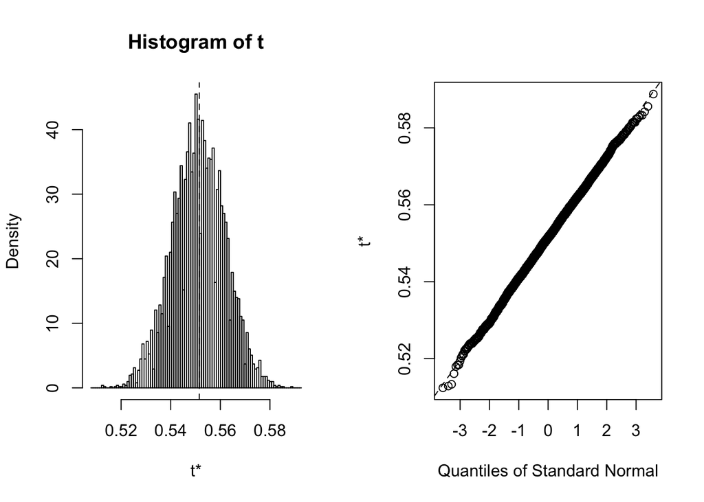

```r
boyle_PJ <- subset(original_subset, original_subset$counter_PJ ==
    1 & original_subset$SENTENCE_JUDGE == "Maura  Slattery Boyle")
boyle_PJ_2 <- c(boyle_PJ["CLASS"], boyle_PJ["converted_sentence"])
boyle_PJ_2 <- data.frame(boyle_PJ_2)
f_abovemedian <- function(data, indices) {
    sample1 <- data[indices, ]
    sum(sample1$CLASS == "1" & sample1$converted_sentence > median_1 |
        sample1$CLASS == "2" & sample1$converted_sentence > median_2 |
        sample1$CLASS == "3" & sample1$converted_sentence > median_3 |
        sample1$CLASS == "4" & sample1$converted_sentence > median_4 |
        sample1$CLASS == "X" & sample1$converted_sentence > median_X,
        na.rm = TRUE)/sum(sample1$CLASS == "1" | sample1$CLASS ==
        "2" | sample1$CLASS == "3" | sample1$CLASS == "4" | sample1$CLASS ==
        "X", na.rm = TRUE)
}
boyle_PJ_boot <- boot(boyle_PJ_2, f_abovemedian, R = 6000)
plot(boyle_PJ_boot)
```

```r
boot.ci(boyle_PJ_boot)
```

```
## BOOTSTRAP CONFIDENCE INTERVAL CALCULATIONS
## Based on 6000 bootstrap replicates
##
## CALL :
## boot.ci(boot.out = boyle_PJ_boot)
##
## Intervals :
## Level      Normal              Basic
## 95%   ( 0.5309,  0.5724 )   ( 0.5313,  0.5731 )
##
## Level     Percentile            BCa
## 95%   ( 0.5299,  0.5718 )   ( 0.5294,  0.5718 )
## Calculations and Intervals on Original Scale
```

```r
sum(original_subset$counter_abovemedian, na.rm = TRUE)/sum(original_subset$counter_PJ,
    na.rm = TRUE)
```

```
## [1] 0.4709839
```

Then we’ll do the same thing for the class 4 prison percent measure.

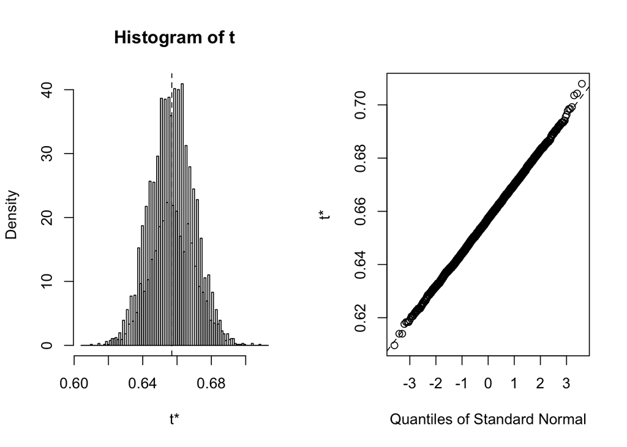

```r
boyle_class4 <- subset(original_subset, original_subset$CLASS ==
    4 & original_subset$SENTENCE_JUDGE == "Maura  Slattery Boyle")
f_prisonpercent <- function(data, indices) {
    sample1 <- data[indices, ]
    sum(sample1$counter_F4_pj == 1, na.rm = TRUE)/sum(sample1$counter_F4,
        na.rm = TRUE)
}
boyle_PJ_boot <- boot(boyle_class4, f_prisonpercent, R = 6000)
plot(boyle_PJ_boot)
```

```r
boot.ci(boyle_PJ_boot)
```

```
## BOOTSTRAP CONFIDENCE INTERVAL CALCULATIONS
## Based on 6000 bootstrap replicates
##
## CALL :
## boot.ci(boot.out = boyle_PJ_boot)
##
## Intervals :
## Level      Normal              Basic
## 95%   ( 0.6316,  0.6819 )   ( 0.6315,  0.6817 )
##
## Level     Percentile            BCa
## 95%   ( 0.6322,  0.6824 )   ( 0.6307,  0.6810 )
## Calculations and Intervals on Original Scale
```

```r
sum(original_subset$counter_F4_pj, na.rm = TRUE)/sum(original_subset$counter_F4,
    na.rm = TRUE)
```

```
## [1] 0.5340984
```

In both cases, the 95% confidence interval constructed from Judge Slattery Boyle’s subset of sentences does not include the actual value of our measure (not even close). In other words, Judge Slattery Boyle’s severe sentencing practices are statistically significant at 5% (also at 1%).

# Closing Thoughts

In conclusion, it’s worth mentioning here that just because a judge seems to sentence more harshly than his or her colleagues (i.e. their severity metric is above the overall average), that does not mean that judge is necessarily more severe. While cases are assigned randomly, further statistical testing is necessary to establish whether such a disparity is significant. In the case of Judge Slattery Boyle, the disparity is statistically significant, as shown by the bootstrap confidence intervals.

That’s it! As previously mentioned, all code used is available, so please expand upon our work.